# InVivoStat Equivalence Test Analysis

## Response and equivalence bound

The Resp10 response is currently being analysed by the Equivalence (TOST) test Analysis module.

The upper equivalence bound is defined as a 10 % (increase) change from the control group mean. This is equivalent to an absolute change of size 0.05. As only an upper bound has been defined a one-sided equivalence test has been performed.

## Scatterplot of the observed data

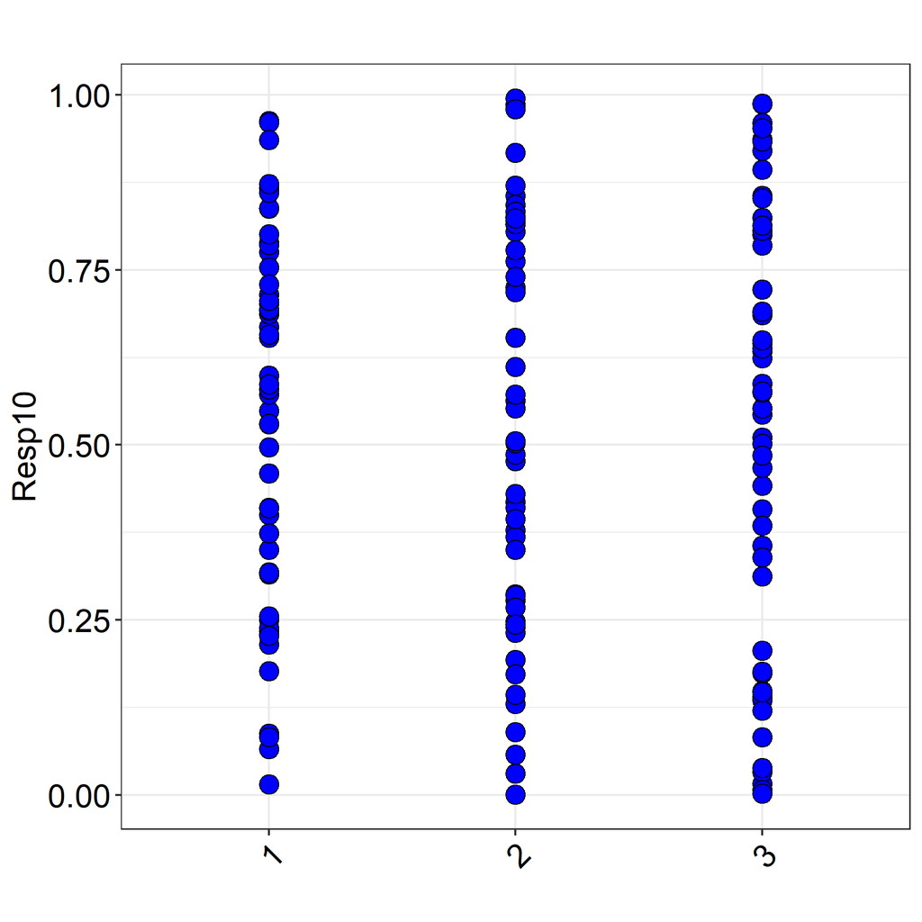

Tip: Use this plot to identify possible outliers.

## Model coefficients

|  | Estimate | Std. Error | t-value | p-value |
| --- | --- | --- | --- | --- |
| (Intercept) | 0.5262 | 0.0226 | 23.26 | < 0.0001 |
| Treat91 | 0.0039 | 0.0320 | 0.12 | 0.9032 |
| Treat92 | 0.0059 | 0.0320 | 0.18 | 0.8543 |

## Table of the least square (predicted) means with 95% confidence intervals

| Mean ID | Treat9 | Mean | Lower 95% CI | Upper 95% CI |
| --- | --- | --- | --- | --- |
| 1 | '1' | 0.530 | 0.453 | 0.608 |
| 2 | '2' | 0.532 | 0.455 | 0.610 |
| 3 | '3' | 0.516 | 0.439 | 0.594 |

## Plot of the least square (predicted) means with 95% confidence intervals

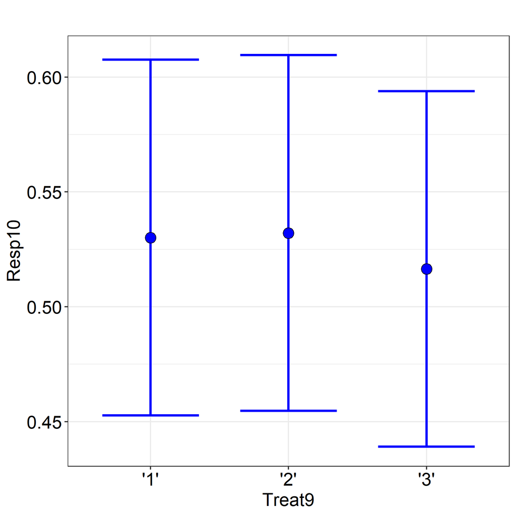

## All to one pairwise equivalence assessments

| Comparison | Difference | Upper one-sided 95% CI | Upper equivalence bound | Equivalence assessment |
| --- | --- | --- | --- | --- |
| '2' - '1' | 0.002 | 0.094 | 0.053 | Inconclusive |
| '3' - '1' | -0.014 | 0.078 | 0.053 | Inconclusive |

## Plot of the comparisons between the predicted means with 95% one-sided confidence interval along with equivalence bound

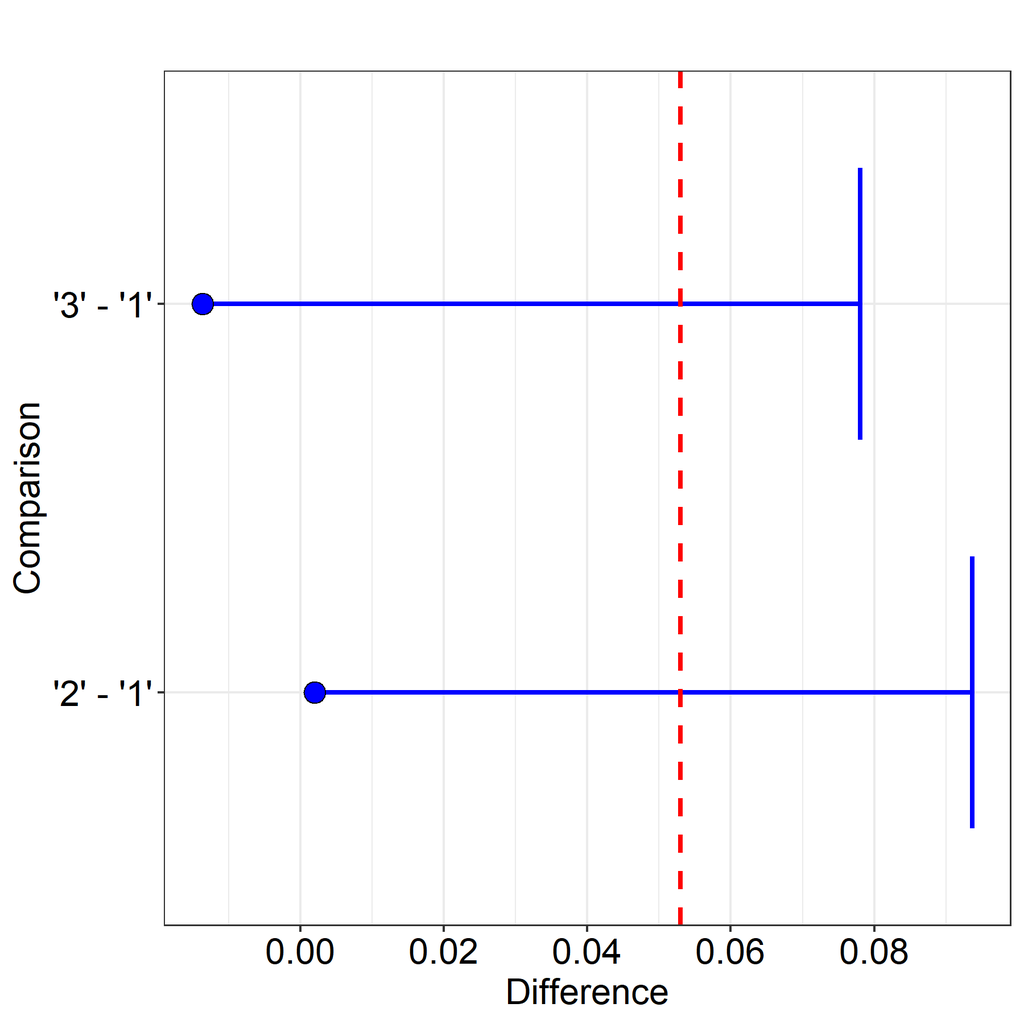

## Conclusion

Conclusion: There are no equivalent means.

## Diagnostic plot

### Residuals vs. predicted plot

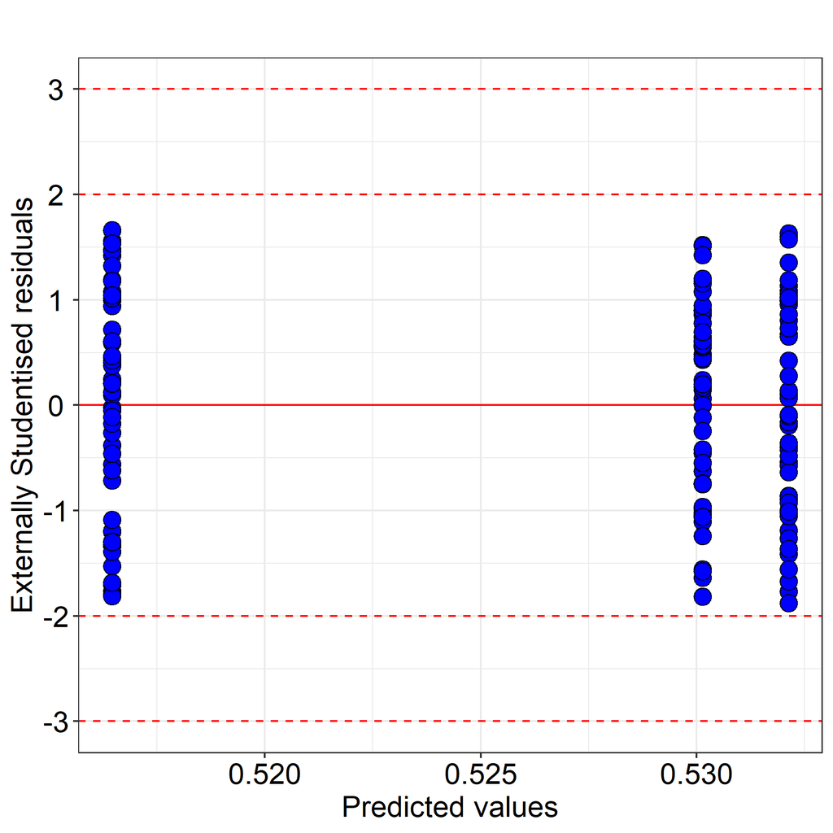

Tip: On this plot look to see if the spread of the points increases as the predicted values increase. If so the response may need transforming.

Tip: Any observation with a residual less than -3 or greater than 3 (SD) should be investigated as a possible outlier.

## Analysis description

The data were analysed using a one-sided equivalence test, see Limentani et al. 2005, with Treat9 as the treatment factor.

For more information on the theoretical approaches that are implemented within this module, see Bate and Clark (2014).

## References

When referring to InVivoStat, please cite 'InVivoStat, version 5.2.0'.

Bate, S.T. and Clark, R.A. (2014). The Design and Statistical Analysis of Animal Experiments. Cambridge University Press.

Limentani, G.B., Ringo, M.C., Ye, F., Bergquist, M.L. and MCSorley E.O. (2005). Beyond the t-test: Statistical equivalence testing. Analytical Chemistry, 77(11), 221-226.